# Analyzing herbivory data

Many ecologists collect data on leaf area loss (aka, herbivory). Usually this is in the form of ‘standing herbivory’, i.e., the area of leaf absent at time0. A ‘herbivory rate’ measures the leaf area loss betwen time0 and time1.

## I. Data

Leaf area loss can be measured in a variety of ways.

### I.a. Binary: Eaten vs uneaten

At its simplest, one can record whether a leaf suffered any herbivory or not, as a binary response variable (1 = eaten, 0 = uneaten).

### I.b. Ordinal categories: Eaten a lot > eaten a bit > uneaten

A refinement of this binary data would be to record leaf area loss along some ordinal scale (e.g., leaf entirely eaten, leaf mostly eaten, leaf partly eaten, leaf uneaten). Similarly, one could assign quantitative values to these categories (e.g., >95%, 50–94%, 5–49%, 0–4% area lost). Often, these categories are recoded as numbers. These categories could be estimated by eye, counted using a transparent grid, or measured exactly using image analysis software. In all cases, the ordinal structure of the data remains, even if recoded as a numeric vector.

### I.c. Continuous: Absolute area lost, percentage

Finally, leaf area loss can be quantified precisely using a transparent grid or image analysis. In this, leaf area loss can be expressed either as an exact percentage (e.g., 17.8%), proportion (0.178), or absolute area (e.g., 12.3cm^2 eaten and 56.8cm^2 uneaten).

### I.d. Example data

In this example, we ‘collected’ data on 10 leaves from 10 individuals (Ind) of two species (A and B).

```r
# generate random herbivory data
LFbinA <- rbinom(100, 1, 0.65) # species A is eaten a lot
LFbinB <- rbinom(100, 1, 0.25) # species B is not
LFbin  <- c(LFbinA, LFbinB)

LFeat <- round(runif(200, 0, 100), 2) # generate uniform distribution of %age herbivory
LFeat[LFbin == 0] <- 0.00 # add 0 bin herbivory to %age

LFnot <- round(runif(200, 10, 200), 2) # generate area of leaf not eaten (and variable leaf area)
LArea <- LFeat + LFnot  # leaf total area
Lperc <- round(LFeat / LArea, 2)  # percentage eaten of total area

LFcat <- factor(200, levels = c('all', 'most', 'some', 'none')) # categorise herbivory
LFcat[Lperc >= 0.95] <- 'all'
LFcat[Lperc < 0.95 & Lperc >= 0.5] <- 'most'
LFcat[Lperc >= 0.05 & Lperc < 0.5] <- 'some'
LFcat[Lperc < 0.05] <- 'none'

Ind <- rep(1:10, each = 10, times = 2) # col for individuals
Spp <- rep(c('A', 'B'), each = 100) # code for species A and B.

herb <- data.frame(Spp, Ind, LArea, LFeat, LFnot, Lperc, LFcat, LFbin)
head(herb)
```

```
##   Spp Ind  LArea LFeat  LFnot Lperc LFcat LFbin
## 1   A   1  20.10  0.00  20.10  0.00  none     0
## 2   A   1 114.25  0.00 114.25  0.00  none     0
## 3   A   1 215.64 30.99 184.65  0.14  some     1
## 4   A   1 201.67 99.69 101.98  0.49  some     1
## 5   A   1  89.75 77.34  12.41  0.86  most     1
## 6   A   1 200.01 13.69 186.32  0.07  some     1
```

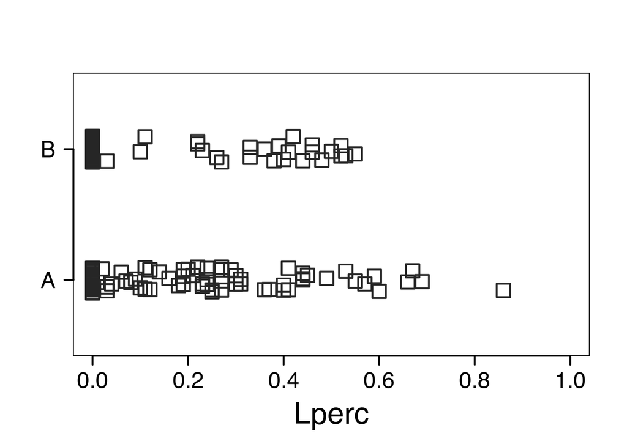

```r
stripchart(Lperc ~ Spp, data = herb,
           las = 1, lwd = 2,
           cex = 2, cex.lab= 2, cex.axis = 1.5,
           xlim = c(0, 1), ylim = c(0.5, 2.5),
           col = 'grey15',
           method = 'jitter')
```

# II. Analysis

Analysis of herbivory data is often carried out with a linear model or ANOVA. This approach has two problems.

1. A linear model or ANOVA assumes data with a Normal distribution of residuals. This assumption is violated with percentage data, which is bounded between 0 and 100.
2. Herbivory data is also often 0-inflated (there are many leaves with 0 herbivory).

There are several ways to analyse herbivory data that are better than a linear model. We will explore some here, from simple to more complex data and models.

## Approach 1. Analysis using leaf eaten/not

### 1.a. Simple Chi-squared / logistic analysis

Count up the number of eaten and uneaten leaves per species; test with ChiSq or a logistic regression.

```r
chisq.test(table(herb$Spp, herb$LFbin))
```

```
##
##  Pearson's Chi-squared test with Yates' continuity correction
##
## data:  table(herb$Spp, herb$LFbin)
## X-squared = 22.352, df = 1, p-value = 2.27e-06
```

```r
summary( glm(LFbin ~ Spp, data = herb, family = 'binomial') )
```

```
##
## Call:
## glm(formula = LFbin ~ Spp, family = "binomial", data = herb)
##
## Deviance Residuals:
##     Min       1Q   Median       3Q      Max
## -1.3354  -0.7585  -0.7585   1.0273   1.6651
##
## Coefficients:
##             Estimate Std. Error z value Pr(>|z|)
## (Intercept)   0.3640     0.2033   1.790   0.0734 .
## SppB         -1.4626     0.3077  -4.753    2e-06 ***
## ---
## Signif. codes:  0 '***' 0.001 '**' 0.01 '*' 0.05 '.' 0.1 ' ' 1
##
## (Dispersion parameter for binomial family taken to be 1)
##
##     Null deviance: 272.12  on 199  degrees of freedom
## Residual deviance: 247.84  on 198  degrees of freedom
## AIC: 251.84
##
## Number of Fisher Scoring iterations: 4
```

Species A leaves are eaten more often.

But, these are not independent samples, because leaves are nested on individual trees of each species. (If we had only 1 random leaf from each tree, that might be ok).

### 1.b. Calculate individual-level data

To help with the multiple leaves from individuals, we could run a group (i.e., groups of leaves on individual trees) binomial regression.

```r
# count number of leaves per individual
tmp <- tapply(herb$LFbin, list(herb$Spp, herb$Ind), sum)
Neat <- c(tmp['A', ], tmp['B', ]) # number eaten
Nnot <- 10 - Neat  # we sampled 10 leaves per tree
herb_ind <- data.frame(Spp = rep(c('A', 'B'), each = 10),
                       Neat, Nnot)
y <- cbind(Neat, Nnot) # create response variable for glm

# group-level glm
summary(glm(y ~ herb_ind$Spp, family = 'binomial'))
```

```
##
## Call:
## glm(formula = y ~ herb_ind$Spp, family = "binomial")
##
## Deviance Residuals:
##      Min        1Q    Median        3Q       Max
## -2.52350  -0.42414   0.06438   0.72053   2.34025
##
## Coefficients:
##               Estimate Std. Error z value Pr(>|z|)
## (Intercept)     0.3640     0.2033   1.790   0.0734 .
## herb_ind$SppB  -1.4626     0.3077  -4.753    2e-06 ***
## ---
## Signif. codes:  0 '***' 0.001 '**' 0.01 '*' 0.05 '.' 0.1 ' ' 1
##
## (Dispersion parameter for binomial family taken to be 1)
##
##     Null deviance: 51.099  on 19  degrees of freedom
## Residual deviance: 26.821  on 18  degrees of freedom
## AIC: 79.574
##
## Number of Fisher Scoring iterations: 4
```

### 1.c. Mixed-effects model

We could also run a mixed effects model at the leaf level, using a random effect to group the leaves on trees.

```r
library(lme4)
summary( glmer(LFbin ~ Spp + (1|Ind), family = 'binomial') )
```

```
## Generalized linear mixed model fit by maximum likelihood (Laplace
##   Approximation) [glmerMod]
##  Family: binomial  ( logit )
## Formula: LFbin ~ Spp + (1 | Ind)
##
##      AIC      BIC   logLik deviance df.resid
##    253.3    263.2   -123.6    247.3      197
##
## Scaled residuals:
##     Min      1Q  Median      3Q     Max
## -1.3541 -0.6215 -0.5284  0.8137  2.0204
##
## Random effects:
##  Groups Name        Variance Std.Dev.
##  Ind    (Intercept) 0.08971  0.2995
## Number of obs: 200, groups:  Ind, 10
##
## Fixed effects:
##             Estimate Std. Error z value Pr(>|z|)
## (Intercept)   0.3720     0.2267   1.641    0.101
## SppB         -1.4930     0.3144  -4.749 2.04e-06 ***
## ---
## Signif. codes:  0 '***' 0.001 '**' 0.01 '*' 0.05 '.' 0.1 ' ' 1
##
## Correlation of Fixed Effects:
##      (Intr)
## SppB -0.602
```

## Approach 2. Continuous percentage data

The problems with continous quantitative data on the percentage of leaf area lost to herbivory, as stated above, are that the data are bounded by 0 and 1 (thus not Normal) and are often zero-inflated.

### 2.a. ANOVA/linear model: Not recommended

Analysis of herbivory data is often carried out with a linear model or ANOVA. This approach has the two problems identified above and is not recommended.

### 2.b. Arcsine square-root transformation: Not recommended

The arcsine square-root transformation is a standard procedure for analyzing proportion data in ecology, but suffers from a lack of interpretability.

For binomial data (*x* out of *n*), logistic regression is easier to interpret and is more powerful. For non-binomial data (e.g., continuous percentages), the arcsine transformation is hard to interpret and can give wrong results.

For more details, see: Warton & Hui. 2011. The arcsine is asinine: the analysis of proportions in ecology. *Ecology* 92, 3–10. [PDF](https://www.researchgate.net/publication/51115657_The_arcsine_is_asinine_the_analysis_of_proportions_in_ecology)

```r
# arcsine transformation
herb$LFarc <- asin(sqrt(herb$Lperc))
# linear model
summary(lm(LFarc ~ Spp, data = herb))
```

```
##
## Call:
## lm(formula = LFarc ~ Spp, data = herb)
##
## Residuals:
##     Min      1Q  Median      3Q     Max
## -0.3238 -0.1571 -0.1571  0.2226  0.8635
##
## Coefficients:
##             Estimate Std. Error t value Pr(>|t|)
## (Intercept)  0.32382    0.03053  10.606  < 2e-16 ***
## SppB        -0.16671    0.04318  -3.861 0.000153 ***
## ---
## Signif. codes:  0 '***' 0.001 '**' 0.01 '*' 0.05 '.' 0.1 ' ' 1
##
## Residual standard error: 0.3053 on 198 degrees of freedom
## Multiple R-squared:  0.07002,    Adjusted R-squared:  0.06532
## F-statistic: 14.91 on 1 and 198 DF,  p-value: 0.0001529
```

### 2.c. Beta regression: Recommended

Continuous proportions can be analysed with beta regression models. These techniques: - model proportions on their original scale, which makes statistical inference more straightforward and, - produce less biased estimates relative to transformation-based solutions.

For more details, see: Douma & Weedon. 2018. Analysing continuous proportions in ecology and evolution: A practical introduction to beta and Dirichlet regression. Methods in Ecology & Evolution 10, 1412–1430. [PDF](https://besjournals.onlinelibrary.wiley.com/doi/full/10.1111/2041-210X.13234)

```r
# beta regression for %age data: glmmTMB package
library(glmmTMB)
```

Try a simple beta regression model.

```r
#bm1 <- glmmTMB(Lperc ~ Spp, data = herb,
#               family = beta_family(link = "logit"))
```

Simple beta regressions require data to be 0 < y < 1.

Rescale the data to remove 0s and 1s.

```r
transform01 <- function(x) {
  (x * (length(x) - 1) + 0.5) / (length(x))
}

herb$Lperc.scaled <- transform01(herb$Lperc)
```

Run the rescaled model.

```r
bm2 <- glmmTMB(Lperc.scaled ~ Spp, data = herb,
               family = beta_family(link = "logit"))
summary(bm2)
```

```
##  Family: beta  ( logit )
## Formula:          Lperc.scaled ~ Spp
## Data: herb
##
##      AIC      BIC   logLik deviance df.resid
##   -695.5   -685.6    350.8   -701.5      197
##
##
## Dispersion parameter for beta family (): 2.45
##
## Conditional model:
##             Estimate Std. Error z value Pr(>|z|)
## (Intercept)  -1.6707     0.1286 -12.988  < 2e-16 ***
## SppB         -0.4771     0.1507  -3.167  0.00154 **
## ---
## Signif. codes:  0 '***' 0.001 '**' 0.01 '*' 0.05 '.' 0.1 ' ' 1
```

#### 2.c.i. Mixed-effects beta regression

Run a mixed-effects model to account for multiple leaves from the same tree.

```r
bm3 <- glmmTMB(Lperc.scaled ~ Spp + (1|Ind), data = herb,
               family = beta_family(link = "logit"))
summary(bm3)
```

```
##  Family: beta  ( logit )
## Formula:          Lperc.scaled ~ Spp + (1 | Ind)
## Data: herb
##
##      AIC      BIC   logLik deviance df.resid
##   -693.5   -680.3    350.8   -701.5      196
##
## Random effects:
##
## Conditional model:
##  Groups Name        Variance  Std.Dev.
##  Ind    (Intercept) 1.255e-09 3.543e-05
## Number of obs: 200, groups:  Ind, 10
##
## Dispersion parameter for beta family (): 2.45
##
## Conditional model:
##             Estimate Std. Error z value Pr(>|z|)
## (Intercept)  -1.6707     0.1286 -12.988  < 2e-16 ***
## SppB         -0.4771     0.1507  -3.167  0.00154 **
## ---
## Signif. codes:  0 '***' 0.001 '**' 0.01 '*' 0.05 '.' 0.1 ' ' 1
```

#### 2.c.ii. Zero-augmented beta regression model

Can be run with the R package `brms`. For details see Douma & Weedon. 2018, Appendix 3.

## Approach 3. Ordinal scale data

Ordinal data is an extension of binomial data, except instead of a binary response variable, we use an ordered factor response variable. In this case, we use ordinal logistic regression. Remember that in terms of herbivory, these data could be: eaten a lot > eatn a bit > uneaten; or categorical bins of leaf area loss (e.g., <90%, 50-89%, 5-49%, 0-4%).

The package to use here is `ordinal`, which contains the two functions `clm()` and `clmm()`.

There are two good tutorials.

Ordinal logistic regression in R: https://marissabarlaz.github.io/portfolio/ols/

Ordinal regression in R: part 1: https://tdunn.ca/posts/2020-03-15-ordinal-regression-in-r-part-1/

If you want to use a Bayesian approach: https://tdunn.ca/posts/2020-03-17-ordinal-regression-in-r-part-2/

```r
library(ordinal)
```

#### Simple or multiple ordinal logistic regression

The function `clm()` handles simple and multiple ordinal logistic regression models.

```r
ols1 <- clm(LFcat ~ Spp, data = herb)
summary(ols1)
```

```
## formula: LFcat ~ Spp
## data:    herb
##
##  link  threshold nobs logLik  AIC    niter max.grad cond.H
##  logit flexible  200  -161.43 328.86 5(0)  6.09e-09 7.9e+00
##
## Coefficients:
##      Estimate Std. Error z value Pr(>|z|)
## SppB   1.2514     0.3036   4.122 3.76e-05 ***
## ---
## Signif. codes:  0 '***' 0.001 '**' 0.01 '*' 0.05 '.' 0.1 ' ' 1
##
## Threshold coefficients:
##           Estimate Std. Error z value
## most|some  -2.1332     0.2935  -7.267
## some|none   0.1224     0.1963   0.623
```

#### Mixed effects ordinal logistic regression

The function `clmm()` handles simple and multiple ordinal logistic regression models that include random effects.

```r
ols2 <- clmm(LFcat ~ Spp + (1|Ind), data = herb)
summary(ols2)
```

```
## Cumulative Link Mixed Model fitted with the Laplace approximation
##
## formula: LFcat ~ Spp + (1 | Ind)
## data:    herb
##
##  link  threshold nobs logLik  AIC    niter    max.grad cond.H
##  logit flexible  200  -161.11 330.22 112(232) 4.91e-06 2.9e+01
##
## Random effects:
##  Groups Name        Variance Std.Dev.
##  Ind    (Intercept) 0.09098  0.3016
## Number of groups:  Ind 10
##
## Coefficients:
##      Estimate Std. Error z value Pr(>|z|)
## SppB   1.2682     0.3071   4.129 3.64e-05 ***
## ---
## Signif. codes:  0 '***' 0.001 '**' 0.01 '*' 0.05 '.' 0.1 ' ' 1
##
## Threshold coefficients:
##           Estimate Std. Error z value
## most|some  -2.1681     0.3128   -6.93
## some|none   0.1189     0.2201    0.54
```